# KNN_Classification

K Nearest Neighbor(KNN) is a very `simple`, `easy to understand`, `versatile` and one of the topmost machine learning algorithms.

KNN used in the variety of applications such as `finance`, `healthcare`, `political science`, `handwriting detection`, `image recognition` and `video recognition`.

- In Credit ratings, financial institutes will predict the credit rating of customers.
- In loan disbursement, banking institutes will predict whether the loan is safe or risky.
- In political science, classifying potential voters in two classes will vote or won’t vote.

KNN algorithm used for both `classification` and `regression` problems. KNN algorithm based on `feature similarity` approach.

### Outline

- K-Nearest Neighbor Algorithm
- How does the KNN algorithm work?
- Eager Vs Lazy learners
- How do you decide the number of neighbors in KNN?
- Curse of Dimensionality
- Classifier Building in Scikit-learn
- Pros and Cons
- How to improve KNN performance?

#### KNN is a `non-parametric` and `lazy learning` algorithm.

- Non-parametric means there is `no assumption` for underlying data distribution. In other words, the model structure determined from the dataset. This will be very helpful in practice where most of the real world datasets do not follow mathematical theoretical assumptions.
- Lazy algorithm means it `does not need any training data points` for model generation. All training data used in the testing phase. This makes training faster and testing phase slower and costlier. Costly testing phase means time and memory. In the worst case, KNN needs more time to scan all data points and scanning all data points will require more memory for storing training data.

#### How does the KNN algorithm work?

In KNN, K is the number of nearest neighbors. The number of neighbors is the core deciding factor. K is generally an odd number if the number of classes is 2. When K=1, then the algorithm is known as the nearest neighbor algorithm. This is the simplest case. Suppose P1 is the point, for which label needs to predict. First, you find the one closest point to P1 and then the label of the nearest point assigned to P1.

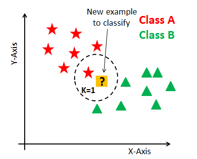

Suppose **P1** is the point, for which label needs to predict. First, you find the **k** closest point to **P1** and then classify points by `majority vote` of its `k neighbors`. Each object votes for their class and the class with the most votes is taken as the prediction. For finding closest similar points, you find the distance between points using distance measures such as `Euclidean distance`, `Hamming distance`, `Manhattan distance` and `Minkowski distance`.

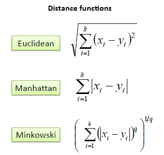

It should also be noted that all three distance measures are only valid for continuous variables. In case of categorical variables the Hamming distance must be used. It also brings up the issue of standardization of the numerical variables between 0 and 1 when there is a mixture of numerical and categorical variables in the dataset.

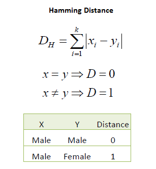

#### KNN has the following basic steps:

1. Calculate distance
2. Find closest neighbors
3. Vote for labels

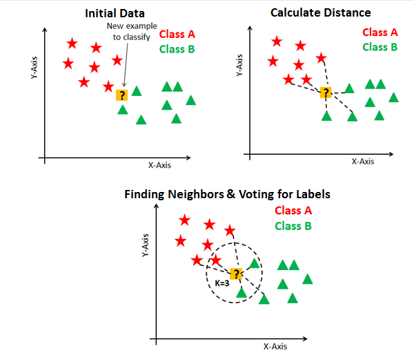

#### Eager Vs. Lazy Learners

Eager learners mean when given training points will construct a `generalized model` before performing prediction on given new points to classify. You can think of such learners as being ready, active and eager to classify unobserved data points.

`Lazy Learning` means there is no need for `learning or training` of the model and all of the data points used at the time of prediction. Lazy learners wait until the last minute before classifying any data point. Lazy learner stores merely the training dataset and waits until classification needs to perform. Only when it sees the test tuple does it perform generalization to classify the tuple based on its similarity to the stored training tuples.

Unlike eager learning methods, lazy learners do `less work in the training phase` and `more work in the testing phase` to make a classification. Lazy learners are also known as **instance-based learners** because lazy learners store the training points or instances, and all learning is based on instances.

#### Curse of Dimensionality

KNN performs `better with a lower number of features` than a `large number of features`. You can say that when the number of features increases than it requires more data. Increase in dimension also leads to the problem of overfitting. To avoid overfitting, the needed data will need to grow exponentially as you increase the number of dimensions. This problem of higher dimension is known as the Curse of Dimensionality.

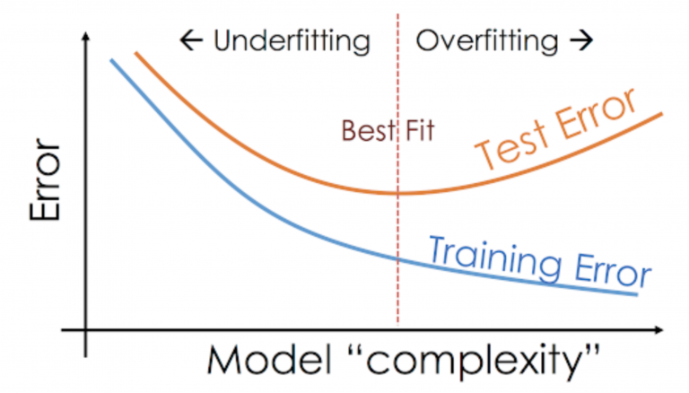

To deal with the problem of the curse of dimensionality, you need to perform `principal component analysis` before applying any machine learning algorithm, or you can also use `feature subset selection` approach.

Research has shown that in large dimension `Euclidean distance` is not useful anymore. Therefore, you can prefer other measures such as `cosine similarity`, which get decidedly less affected by high dimension.

[figure not shown]

#### How do you decide the number of neighbors in KNN?

The number of neighbors(K) in KNN is a hyperparameter that you need choose at the time of model building. You can think of K as a controlling variable for the prediction model.

Research has shown that no optimal number of neighbors suits all kind of data sets. Each dataset has it's own requirements. In the case of a small number of neighbors, the noise will have a higher influence on the result, and a large number of neighbors make it computationally expensive.

Research has also shown that a small amount of neighbors are most flexible fit which will have `low bias but high variance` and a large number of neighbors will have a smoother decision boundary which means `lower variance but higher bias`.

#### High bias means underfitting and High variance means overfitting

In general, a `large K` value is more precise as it reduces the overall noise but there is no guarantee. `Cross-validation` is another way to retrospectively determine a good `K` value by using an independent dataset to validate the `K` value. Historically, the optimal `K` for most datasets has been between `3-10`. That produces much better results than `1-NN`.

Generally, Data scientists choose as an `odd number` if the number of `classes are even`.

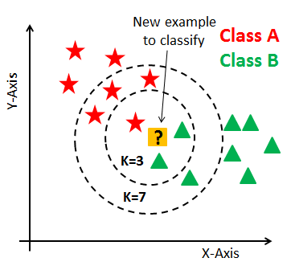

#### Classifier Building in Scikit-learn

```python
import pandas as pd
```

```python
# Assigning features and label variables
# First Feature
weather=['Sunny','Sunny','Overcast','Rainy','Rainy','Rainy','Overcast','Sunny','Sunny',
'Rainy','Sunny','Overcast','Overcast','Rainy']
# Second Feature
temp=['Hot','Hot','Hot','Mild','Cool','Cool','Cool','Mild','Cool','Mild','Mild','Mild','Hot','Mild']

# Label or target varible
play=['No','No','Yes','Yes','Yes','No','Yes','No','Yes','Yes','Yes','Yes','Yes','No']
```

```python
# Import LabelEncoder
from sklearn import preprocessing
#creating labelEncoder
le = preprocessing.LabelEncoder()
# Converting string labels into numbers.
weather_encoded=le.fit_transform(weather)
print(weather_encoded)
```

```
[2 2 0 1 1 1 0 2 2 1 2 0 0 1]
```

```python
# converting string labels into numbers
temp_encoded=le.fit_transform(temp)
label=le.fit_transform(play)
```

```python
#combinig weather and temp into single listof tuples
features=list(zip(weather_encoded,temp_encoded))
```

```python
features
```

```
[(2, 1),
 (2, 1),
 (0, 1),
 (1, 2),
 (1, 0),
 (1, 0),
 (0, 0),
 (2, 2),
 (2, 0),
 (1, 2),
 (2, 2),
 (0, 2),
 (0, 1),
 (1, 2)]
```

```python
label
```

```
array([0, 0, 1, 1, 1, 0, 1, 0, 1, 1, 1, 1, 1, 0])
```

```python
from sklearn.neighbors import KNeighborsClassifier

model = KNeighborsClassifier(n_neighbors=3)

# Train the model using the training sets
model.fit(features,label)

#Predict Output
predicted= model.predict([[0,2]]) # 0:Overcast, 2:Mild
print(predicted)
```

```
[1]
```

### KNN with Multiple Labels

```python
#Import scikit-learn dataset library
from sklearn import datasets

#Load dataset
wine = datasets.load_wine()
```

```python
# print the names of the features
print(wine.feature_names)
```

```
['alcohol', 'malic_acid', 'ash', 'alcalinity_of_ash', 'magnesium', 'total_phenols', 'flavanoids', 'nonflavanoid_phenols', 'proanthocyanins', 'color_intensity', 'hue', 'od280/od315_of_diluted_wines', 'proline']
```

```python
# print the label species(class_0, class_1, class_2)
print(wine.target_names)
```

```
['class_0' 'class_1' 'class_2']
```

```python
print(wine.data[0:5])
```

```
[[1.423e+01 1.710e+00 2.430e+00 1.560e+01 1.270e+02 2.800e+00 3.060e+00
  2.800e-01 2.290e+00 5.640e+00 1.040e+00 3.920e+00 1.065e+03]
 [1.320e+01 1.780e+00 2.140e+00 1.120e+01 1.000e+02 2.650e+00 2.760e+00
  2.600e-01 1.280e+00 4.380e+00 1.050e+00 3.400e+00 1.050e+03]
 [1.316e+01 2.360e+00 2.670e+00 1.860e+01 1.010e+02 2.800e+00 3.240e+00
  3.000e-01 2.810e+00 5.680e+00 1.030e+00 3.170e+00 1.185e+03]
 [1.437e+01 1.950e+00 2.500e+00 1.680e+01 1.130e+02 3.850e+00 3.490e+00
  2.400e-01 2.180e+00 7.800e+00 8.600e-01 3.450e+00 1.480e+03]
 [1.324e+01 2.590e+00 2.870e+00 2.100e+01 1.180e+02 2.800e+00 2.690e+00
  3.900e-01 1.820e+00 4.320e+00 1.040e+00 2.930e+00 7.350e+02]]
```

```python
print(wine.target)
```

```
[0 0 0 0 0 0 0 0 0 0 0 0 0 0 0 0 0 0 0 0 0 0 0 0 0 0 0 0 0 0 0 0 0 0 0 0 0
 0 0 0 0 0 0 0 0 0 0 0 0 0 0 0 0 0 0 0 0 0 0 1 1 1 1 1 1 1 1 1 1 1 1 1 1 1
 1 1 1 1 1 1 1 1 1 1 1 1 1 1 1 1 1 1 1 1 1 1 1 1 1 1 1 1 1 1 1 1 1 1 1 1 1
 1 1 1 1 1 1 1 1 1 1 1 1 1 1 1 1 1 1 1 2 2 2 2 2 2 2 2 2 2 2 2 2 2 2 2 2 2
 2 2 2 2 2 2 2 2 2 2 2 2 2 2 2 2 2 2 2 2 2 2 2 2 2 2 2 2 2 2]
```

```python
print(wine.data.shape)
```

```
(178, 13)
```

```python
print(wine.target.shape)
```

```
(178,)
```

```python
# Import train_test_split function
from sklearn.model_selection import train_test_split

# Split dataset into training set and test set
X_train, X_test, y_train, y_test = train_test_split(wine.data, wine.target, test_size=0.3) # 70% training and 30% test
```

```python
#Import knearest neighbors Classifier model
from sklearn.neighbors import KNeighborsClassifier

#Create KNN Classifier
knn = KNeighborsClassifier(n_neighbors=3)

#Train the model using the training sets
knn.fit(X_train, y_train)

#Predict the response for test dataset
y_pred = knn.predict(X_test)
```

```python
#Import scikit-learn metrics module for accuracy calculation
from sklearn import metrics
# Model Accuracy, how often is the classifier correct?
print("Accuracy:",metrics.accuracy_score(y_test, y_pred))
```

```
Accuracy: 0.6851851851851852
```

```python
#Import knearest neighbors Classifier model
from sklearn.neighbors import KNeighborsClassifier

#Create KNN Classifier
knn = KNeighborsClassifier(n_neighbors=5)

#Train the model using the training sets
knn.fit(X_train, y_train)

#Predict the response for test dataset
y_pred = knn.predict(X_test)
```

```python
#Import scikit-learn metrics module for accuracy calculation
from sklearn import metrics
# Model Accuracy, how often is the classifier correct?
print("Accuracy:",metrics.accuracy_score(y_test, y_pred))
```

```
Accuracy: 0.7777777777777778
```

### Challange-1

Consider the Weather dataset and perform KNN Classification by choosing optimal k-value

### Challange-2

Apply Cross-validation on the given Weather dataset and print the accuracy.